# **Predicting human body posture and movement by using Random Forest Method**

Hum N. Bhandari

11/22/2015

## **Overview**

In this project we use random forest method to develop machine learning model to predict the human acitivity.Only 52 related features were selected after all necessary cleaning procedure.Random forest method was selected because it gave higher accurary in training set, crossvalidation set and testing set.This model has very low out of sample error **0.0050979**.To train this model, train() function was used from caret package with repeated cross validation and elapsed time for training process was **23.09 min**

### **Downloading reading and Cleaning Data**

**Loading related libraries**

we used caret package to apply some built in mahine learning function like train() etc

```r
library(caret)
```

**Downloading Data**

Training data set and test data set were downloaded using R function download.file(). We are making eval = FALSE to avoid download again.

```r
Training_url <- "https://d396qusza40orc.cloudfront.net/predmachlearn/pml-training.csv"
download.file(Training_url,destfile = "pml-training.csv",method = "wget")
Test_url<-"https://d396qusza40orc.cloudfront.net/predmachlearn/pml-testing.csv"
download.file(Test_url,destfile="pml-testing.csv",method="wget")
```

**Loading data**

```r
trainData  <- read.csv("pml-training.csv",  header = T,na.strings = c("","NA","#DIV/0!"))
testData   <- read.csv("pml-testing.csv",header = T,na.strings = c("","NA","#DIV/0!"))
```

Downloaded data was loaded using read.csv() functions by considering “”, “NA”, and “#DIV/0 !” as na.strings.

**Cleaning Data**

```r
trainData <-trainData[,-(1:7)]
testData <- testData[,-(1:7)]
sensorTrainColumns <- grep(pattern = "_belt|_arm|_dumbbell|_forearm",colnames(trainData))
sensorTestColumns <- grep(pattern = "_belt|_arm|_dumbbell|_forearm",colnames(testData))
trainData <- trainData[, c(sensorTrainColumns,153)]
testData <- testData[,c(sensorTestColumns,153)]
```

- I decided to remove first 7 columns of data because these columns do not have important informantion for our project
- Inportant information for our project are column names like belt, arm, dumbell , forearm.So, only these columns were extracted to make smaller training and test datasets.
- This resulted data set with 153 column size

**Handling missing data**

```r
  train_good_columns <- colSums(is.na(trainData)) < nrow(trainData)-1000
  test_good_columns  <- colSums(is.na(testData))  < nrow(testData)
  trainData <- trainData[,train_good_columns]
  testData <- testData[,test_good_columns]
  #dim(trainData) ; ans= 19622    53 ;  dim(testData) ; ans =20 53
  #sum(is.na(trainData));sum(is.na(testData)) // Here results are zero means no more NAs

  #===Checking near zero variance===#
  near_zero_var <- nearZeroVar(trainData,saveMetrics=TRUE)
  if (any(near_zero_var$nzv)) nzv else
    message(" No Probem!! there are no  variables with near zero variance")
```

```
##  No Probem!! there are no  variables with near zero variance
```

One of the major problem in both training and test data sets is that there are many columns in which almost all entries are NAs.We are applying follwing technique to solve this problem

- I found that 100 columns of test data set had all entries NAs and they were removed
- In Training sets these 100 columns had very few non NAs entries(less than 1000).So they were also removed
- This process reduced column size to only 53
- I also checked for variable with near zero variance but it turned out that there were no such variables

**New Training and Cross Vlidation data sets**

```r
InTrain <- createDataPartition(trainData$classe,p=0.75,list=FALSE)
training_set <- trainData[InTrain,]
crv_set      <- trainData[-InTrain,]
dim(training_set); dim(crv_set)
```

```
## [1] 14718    53
```

```
## [1] 4904   53
```

- Now this clean data with 53 features were further divided into training set and cross validation set in the ratio of 75% to 25%
- Cross validation set was created to see the out-of sample error before using this model to test set

## Training by Random Forest

```r
starting_time <- proc.time()
Control <- trainControl(method = "repeatedcv",number = 5)
modelFit <- train(classe ~.,data = training_set, method="rf", trControl = Control)
ending_time <- proc.time()
time_required <- ending_time- starting_time
modelFit
```

```
## Random Forest
##
## 14718 samples
##    52 predictors
##     5 classes: 'A', 'B', 'C', 'D', 'E'
##
## No pre-processing
## Resampling: Cross-Validated (5 fold, repeated 1 times)
## Summary of sample sizes: 11776, 11775, 11775, 11773, 11773
## Resampling results across tuning parameters:
##
##   mtry  Accuracy   Kappa      Accuracy SD  Kappa SD
##    2    0.9904873  0.9879652  0.002510514  0.003178610
##   27    0.9901479  0.9875369  0.001521229  0.001925282
##   52    0.9817905  0.9769605  0.002921917  0.003698547
##
## Accuracy was used to select the optimal model using  the largest value.
## The final value used for the model was mtry = 2.
```

```r
time_required
```

```
##     user   system  elapsed
## 1369.798    8.795 1385.335
```

## **Cross Validating the Model**

```r
crv_predictions <- predict(modelFit,crv_set)
confusionMatrix(crv_predictions,crv_set$classe)
```

```
## Confusion Matrix and Statistics
##
##           Reference
## Prediction    A    B    C    D    E
##          A 1394    4    0    0    0
##          B    1  943    2    0    0
##          C    0    2  852   14    0
##          D    0    0    1  789    0
##          E    0    0    0    1  901
##
## Overall Statistics
##
##                Accuracy : 0.9949
##                  95% CI : (0.9925, 0.9967)
##     No Information Rate : 0.2845
##     P-Value [Acc > NIR] : < 2.2e-16
##
##                   Kappa : 0.9936
##  Mcnemar's Test P-Value : NA
##
## Statistics by Class:
##
##                      Class: A Class: B Class: C Class: D Class: E
## Sensitivity            0.9993   0.9937   0.9965   0.9813   1.0000
## Specificity            0.9989   0.9992   0.9960   0.9998   0.9998
## Pos Pred Value         0.9971   0.9968   0.9816   0.9987   0.9989
## Neg Pred Value         0.9997   0.9985   0.9993   0.9964   1.0000
## Prevalence             0.2845   0.1935   0.1743   0.1639   0.1837
## Detection Rate         0.2843   0.1923   0.1737   0.1609   0.1837
## Detection Prevalence   0.2851   0.1929   0.1770   0.1611   0.1839
## Balanced Accuracy      0.9991   0.9965   0.9963   0.9905   0.9999
```

```r
out_sample_error <- sum(crv_predictions != crv_set$classe)/nrow(crv_set)
```

- This model gave very good prediction not only in training set but also in cross validation set
- Out of sample error was **0.0050979**

## **Saving the Model for future use**

```r
saveRDS(modelFit,"modelFit.RDS")
model = readRDS("modelFit.RDS")
answers <- predict(model,testData)
```

## **Plotting**

Although random model is not good in the sense of interpretability, we can grave some information about important features using varImp() funtion

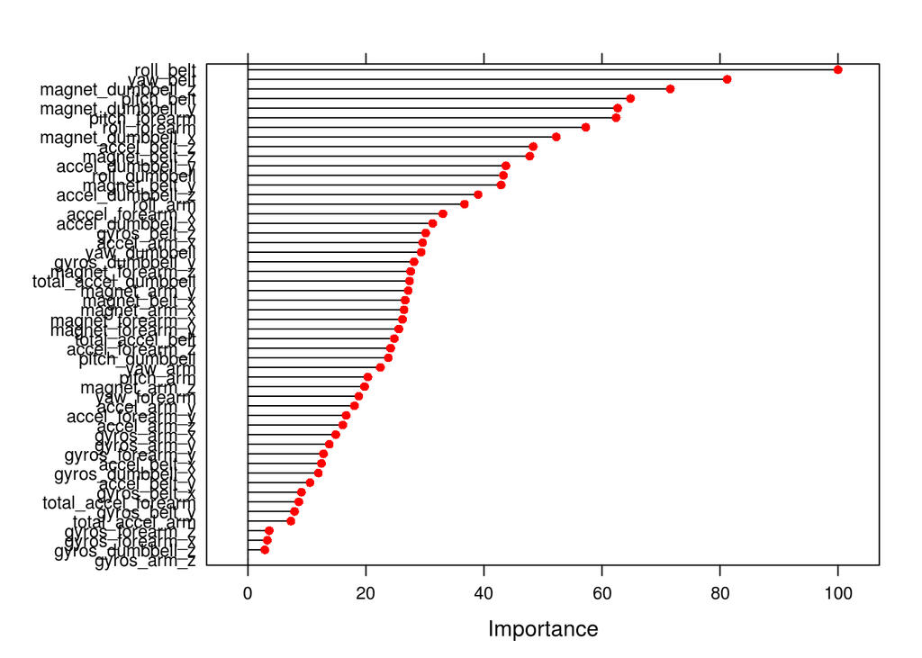

```r
plot( varImp(model),col="red")
```

### **Results submission**

```r
answers <- predict(model,testData)
pml_write_files = function(x){
  n = length(x)
  for(i in 1:n){
    filename = paste0("problem_id_",i,".txt")
    write.table(x[i],file=filename,quote=FALSE,row.names=FALSE,col.names=FALSE)
  }
}

pml_write_files(answers)
```

- I used this model to testing set available as submission part of this project and it gave 100% accurate results

## **References**

- Data Science Specializaton course in [Practical Machine Learning](https://www.coursera.org/course/predmachlearn) offered by Coursrea and John Hopkins University
- Data set was used from [Groupware](http://groupware.les.inf.puc-rio.br/har)
- Original paper is [Wearable Computing: Accelerometers’ Data Classification of Body Postures and Movements. Proceedings of 21st Brazilian Symposium on Artificial Intelligenc](http://groupware.les.inf.puc-rio.br/work.jsf?p1=10335)